# Intro to building maps in R

## 3.3 Tweets data

The `rtweet::tweets_data()` function separates the “*tweets data from users data object.*”

### 3.3.1 `tweets_data()` columns

We repeat the process from above to get a look at the columns we’ll get back from the `rtweet::tweets_data()` function:

```r
tibble::as_tibble(base::intersect(x = base::names(rtweet::tweets_data(TweetsRaw)) ,
                y = base::names(TweetsRaw)))
```

| value |
| --- |
| user_id |
| status_id |
| created_at |
| screen_name |
| text |
| source |
| display_text_width |
| reply_to_status_id |
| reply_to_user_id |
| reply_to_screen_name |

[output cut: 58 more lines]

This dataset will have 68 columns.

### 3.3.2 `TweetsData`

We will store the output from `tweets_data()` in the `TweetsData` object.

```r
TweetsData <- rtweet::tweets_data(TweetsRaw)
glimpse(TweetsData)
```

```
## Rows: 7,974
## Columns: 68
## $ user_id                 <chr> "1274085294934032385", "12…
## $ status_id               <chr> "1457583138553663490", "14…
## $ created_at              <dttm> 2021-11-08 05:37:55, 2021…
## $ screen_name             <chr> "TFFPhilip", "TFFPhilip", …
## $ text                    <chr> "This week has been a toug…
## $ source                  <chr> "Twitter for iPhone", "Twi…
## $ display_text_width      <dbl> 140, 140, 140, 140, 140, 1…
## $ reply_to_status_id      <chr> NA, NA, NA, NA, NA, NA, NA…
## $ reply_to_user_id        <chr> NA, NA, NA, NA, NA, NA, NA…
## $ reply_to_screen_name    <chr> NA, NA, NA, NA, NA, NA, NA…
## $ is_quote                <lgl> FALSE, FALSE, FALSE, FALSE…
## $ is_retweet              <lgl> TRUE, TRUE, TRUE, TRUE, TR…
## $ favorite_count          <int> 0, 0, 0, 0, 0, 0, 0, 0, 0,…
```

[output cut: 55 more lines]

## 3.4 Latitude & longitude data

You may have noticed these data don’t have the latitude or longitude data–we will add these variables below.

### 3.4.1 `lat_lng()` columns

If we look at the help info on the `rtweet::lat_lng()` function, we can see that this will only add two columns to the `TweetsRaw`, `lat` and `lng` (for latitude and longitude).

This would result in quite a few variables, but we don’t need all the variables from `TweetsRaw`.

Fortunately, we now know how to combine `dplyr`’s `select()` function to *only* get the variables we want from `TweetsRaw`, which include `user_id`, `created_at`, `screen_name`, `text`, `retweet_count`, `favorite_count`, `country`, `location`, `country_code` `friends_count`, and the new `lat` and `lng` variables.

```r
TweetsLatLng <- rtweet::lat_lng(TweetsRaw) %>%
  select(user_id, created_at, screen_name, text,
         retweet_count, favorite_count, country,
         location, country_code, friends_count,
         lat, lng)
glimpse(TweetsLatLng)
```

```
## Rows: 7,974
## Columns: 12
## $ user_id        <chr> "1274085294934032385", "12740852949…
## $ created_at     <dttm> 2021-11-08 05:37:55, 2021-11-08 05…
## $ screen_name    <chr> "TFFPhilip", "TFFPhilip", "TFFPhili…
## $ text           <chr> "This week has been a tough one. St…
## $ retweet_count  <int> 47, 33, 59, 39, 20, 64, 34, 31, 39,…
## $ favorite_count <int> 0, 0, 0, 0, 0, 0, 0, 0, 0, 2, 0, 0,…
## $ country        <chr> NA, NA, NA, NA, NA, NA, NA, NA, NA,…
## $ location       <chr> "", "", "", "", "", "", "", "", "",…
## $ country_code   <chr> NA, NA, NA, NA, NA, NA, NA, NA, NA,…
## $ friends_count  <int> 1601, 1601, 1601, 1601, 1601, 1601,…
## $ lat            <dbl> NA, NA, NA, NA, NA, NA, NA, NA, NA,…
## $ lng            <dbl> NA, NA, NA, NA, NA, NA, NA, NA, NA,…
```

### 3.4.2 `lat` & `lng` observations

It’s always good to check how many valid observations we have for the `lat` and `lng` columns, because not every Twitter user allows these data to be collected. We can check this with some help from `dplyr::distinct()`

```r
dplyr::distinct(.data = TweetsLatLng, lat, lng)
```

| lat | lng |
| --- | --- |
| NA | NA |
| 43.06754 | -88.02554250 |
| 33.41287 | -112.42497550 |
| 32.81986 | -96.76175350 |
| 41.57748 | -73.76904250 |
| 34.02079 | -118.41190650 |
| 20.79066 | -103.48477450 |
| 26.53349 | -80.11290350 |
| 31.34225 | 34.96842850 |
| 33.95363 | -118.34615235 |

[output cut: 115 more lines]

We can see this is a small fraction of the overall twitter data, but it’s enough for us to build a map!

## 3.5 Building maps in `ggplot2`

To build a map with `ggplot2`, we need to have a canvas (i.e. data-points) to plot with. We can do this with the `gggplot2::map_data()` function.

### 3.5.1 `map_data("world)`

The `map_data("world")` returns a dataset from the [`maps` package](https://cran.r-project.org/web/packages/maps/readme/README.html) that is “*suitable for plotting with `ggplot2`*”

```r
World <- ggplot2::map_data("world")
World %>% glimpse(78)
```

```
## Rows: 99,338
## Columns: 6
## $ long      <dbl> -69.89912, -69.89571, -69.94219, -70.00415, -70.06612, -70…
## $ lat       <dbl> 12.45200, 12.42300, 12.43853, 12.50049, 12.54697, 12.59707…
## $ group     <dbl> 1, 1, 1, 1, 1, 1, 1, 1, 1, 1, 2, 2, 2, 2, 2, 2, 2, 2, 2, 2…
## $ order     <int> 1, 2, 3, 4, 5, 6, 7, 8, 9, 10, 12, 13, 14, 15, 16, 17, 18,…
## $ region    <chr> "Aruba", "Aruba", "Aruba", "Aruba", "Aruba", "Aruba", "Aru…
## $ subregion <chr> NA, NA, NA, NA, NA, NA, NA, NA, NA, NA, NA, NA, NA, NA, NA…
```

The `World` data is a dataset with latitude (`lat`), longitude (`long`), and group (`group`) values across the entire world. We’re going to use these values to ‘sketch’ a map outline using `geom_point()` and `geom_polygon()` below:

### 3.5.2 `coord_quickmap()` with points

Just like with other plots, we want to build the labels first (we’ll store some information about the data in the labels so it’s clear where it came from).

```r
labs_geom_point <- ggplot2::labs(
  title = "Basic World Map (geom_point)",
  subtitle = "map_data('world')")
```

We will start by creating a map using `geom_point()` layer, but add the `coord_quickmap()` function (which *projects a portion of the earth, which is approximately spherical, onto a flat 2D plane*):

1. Pipe the data to the `ggplot()` function to initialize the plot
2. Add the `geom_point()` layer, specifying the `x` as `long` and `y` as `lat`
3. Include labels

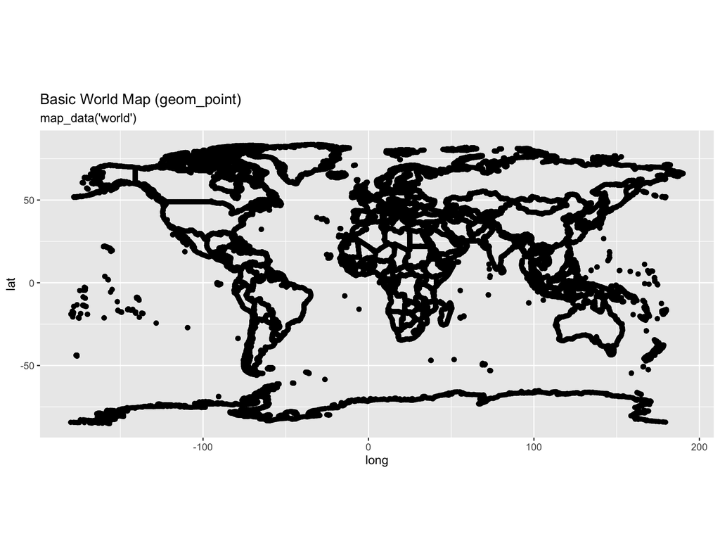

```r
World %>%
  ggplot() + # initializes graph
  geom_point(aes(x = long, y = lat), show.legend = FALSE) +
  coord_quickmap() +
  labs_geom_point
```

What we’ve done here is plot data-points that outline each continent (and fit the spherical location of the `long` and `lat` to a 2-D plane). But the points make the continent outlines sloppy–we should be using lines.

### 3.5.3 `coord_quickmap()` with polygons

We want to convert to point outline into lines, which we can do using `geom_polygon()` (read more about this [here](https://ggplot2-book.org/maps.html#polygonmaps)). The steps are very similar:

1. Pipe the data to the `ggplot()` function to initialize the plot
2. Add the `geom_polygon()` layer, specifying the `x` as `long`, `y` as `lat`, *and `group` as `group`*
3. Include labels

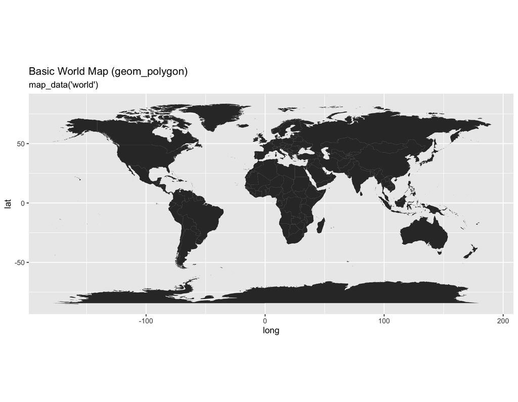

```r
labs_geom_polygon <- ggplot2::labs(
  title = "Basic World Map (geom_polygon)",
  subtitle = "map_data('world')")
World %>%
  ggplot() +
  geom_polygon(aes(x = long, y = lat, group = group)) +
  coord_quickmap() +
  labs_geom_polygon
```

That looks much better, but we should clean it up a bit by removing the `x` and `y` axes, and reducing some of the color contrast.

### 3.5.4 Customizing our map

1. add `fill`, `color` and `alpha` arguments to lighten the color of the continents
2. Include the `ggplot2::theme_void()` layer (specifically designed to remove excess chart junk and give it a ‘minimal’ look)
3. Include labels

We will save this map as `ggp_word_map`

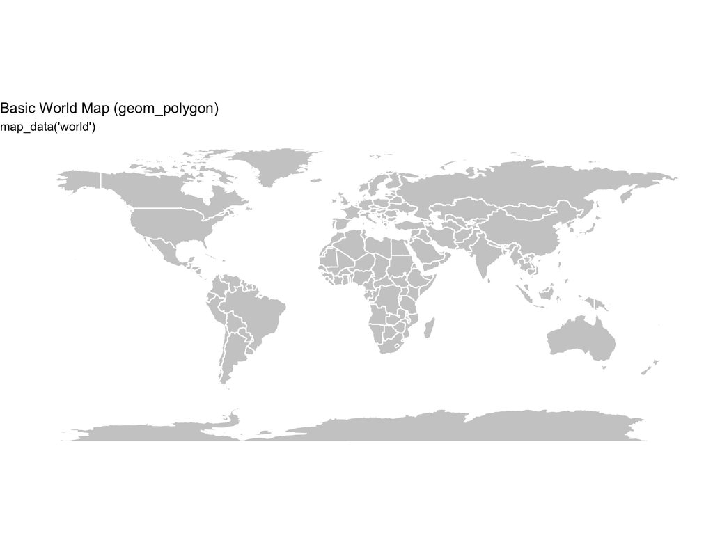

```r
ggp_word_map <- World %>%
  ggplot() +
  geom_polygon(aes(x = long, y = lat, group = group),
               # these are outside the aes() function!
               fill = "grey75", color = "white", alpha = 0.8) +
  coord_quickmap() +
  # add theme
  ggplot2::theme_void() +
  # don't forget the labels
  labs_geom_polygon
ggp_word_map
```

This looks much better! Now we’re ready to add our Twitter data.

### 3.5.5 Map projections

The default map in the `geom_polygon()` is what’s referred to as the `mercator` projection. The [Mercator](https://en.wikipedia.org/wiki/Mercator_projection) projection works well for navigation because the meridians are equally spaced (the grid lines that runs north and south), but the parallels (the lines that run east/west around) are not equally spaced.

This causes a distortion in the land masses at both poles. The map above makes it look like Greenland is roughly 1/2 or 2/3 the size of Africa, when in reality Africa is 14x larger. These are well-known limitations of this projection, so there’s nothing wrong with using it (but it’s good information to know!)

## 3.6 Add twitter data (world)

### 3.6.1 Match variables

Recall that the existing map is using the `World` data (printed below)

```r
glimpse(World)
```

```
## Rows: 99,338
## Columns: 6
## $ long      <dbl> -69.89912, -69.89571, -69.94219, -70.004…
## $ lat       <dbl> 12.45200, 12.42300, 12.43853, 12.50049, …
## $ group     <dbl> 1, 1, 1, 1, 1, 1, 1, 1, 1, 1, 2, 2, 2, 2…
## $ order     <int> 1, 2, 3, 4, 5, 6, 7, 8, 9, 10, 12, 13, 1…
## $ region    <chr> "Aruba", "Aruba", "Aruba", "Aruba", "Aru…
## $ subregion <chr> NA, NA, NA, NA, NA, NA, NA, NA, NA, NA, …
```

We need to rename `lng` to `long`, (so the match the variables names in the `World` data), and remove the data with empty latitude and longitude. Store these new data in `TweetsMap`.

```r
TweetsMap <- TweetsLatLng %>%
  # rename to match
  dplyr::rename(long = lng) %>%
  # remove missing
  filter(!is.na(long) & !is.na(lat))
glimpse(TweetsMap)
```

```
## Rows: 197
## Columns: 12
## $ user_id        <chr> "1391401897035243527", "1485612379"…
## $ created_at     <dttm> 2021-11-08 05:37:26, 2021-11-08 05…
## $ screen_name    <chr> "BarstoolMKE1", "amandaheger613", "…
## $ text           <chr> "BREAKING: Sports media taking Mond…
## $ retweet_count  <int> 0, 0, 0, 0, 0, 1, 0, 0, 0, 0, 0, 0,…
## $ favorite_count <int> 0, 0, 0, 0, 2, 2, 1, 0, 0, 0, 1, 3,…
## $ country        <chr> "United States", "United States", "…
## $ location       <chr> "Milwaukee, WI", "Goodyear, AZ", "G…
## $ country_code   <chr> "US", "US", "US", "US", "US", "US",…
## $ friends_count  <int> 278, 40, 40, 3156, 1424, 3282, 2613…
## $ lat            <dbl> 43.06754, 33.41287, 33.41287, 32.81…
## $ long           <dbl> -88.02554, -112.42498, -112.42498, …
```

### 3.6.2 Add Twitter data layer

We will update the labels:

```r
labs_rtweet_coord_quickmap <- ggplot2::labs(
  title = "  #NFL hashtags = World Map (labs_coord_quickmap())",
  subtitle = "  rtweet data")
```

And add a `ggplot2::geom_point()` to include our tweets on the map:

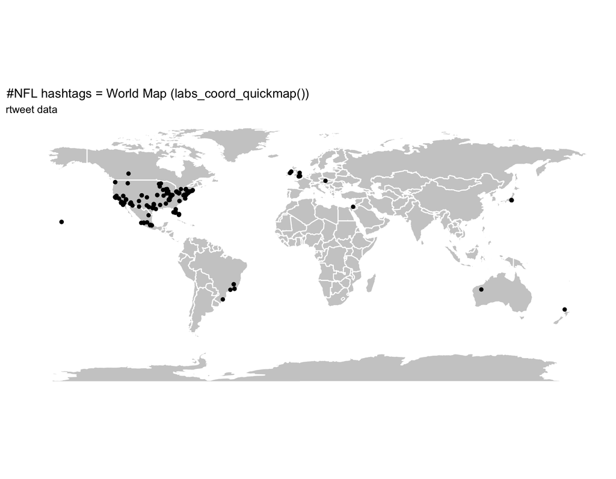

```r
ggp_word_map +
        ggplot2::geom_point(data = TweetsMap,
                        aes(x = long, y = lat)) +
        # add titles/labels
        labs_rtweet_coord_quickmap
```

Now we can see the tweets have been added as data points to the existing map projection! We can see most of these data are limited to the US, so we will build a US map below.

## 3.7 US Maps

We can use the `ggplot2::map_data("usa")` function to create a US map (`USmap`) dataset.

```r
USmap <- ggplot2::map_data("usa")
USmap %>% glimpse(78)
```

```
## Rows: 7,243
## Columns: 6
## $ long      <dbl> -101.4078, -101.3906, -101.3620, -101.3505, -101.3219, -10…
## $ lat       <dbl> 29.74224, 29.74224, 29.65056, 29.63911, 29.63338, 29.64484…
## $ group     <dbl> 1, 1, 1, 1, 1, 1, 1, 1, 1, 1, 1, 1, 1, 1, 1, 1, 1, 1, 1, 1…
## $ order     <int> 1, 2, 3, 4, 5, 6, 7, 8, 9, 10, 11, 12, 13, 14, 15, 16, 17,…
## $ region    <chr> "main", "main", "main", "main", "main", "main", "main", "m…
## $ subregion <chr> NA, NA, NA, NA, NA, NA, NA, NA, NA, NA, NA, NA, NA, NA, NA…
```

We can see these data are very similar to `World`, and have the same `long`, `lat`, and `group` variables.

### 3.7.1 US map (`coord_quickmap()`)

We can plot `USmap` the same way we did above (with `geom_polygon()` and `coord_quickmap()`), after creating a new set of labels:

1. Create labels (offset by a few spaces)
2. Pipe the `USmap` data to the `ggplot()` function to initialize the plot
3. Add the `geom_polygon()` layer, specifying the `x` as `long`, `y` as `lat`, *and `group` as `group`*
4. Add labels

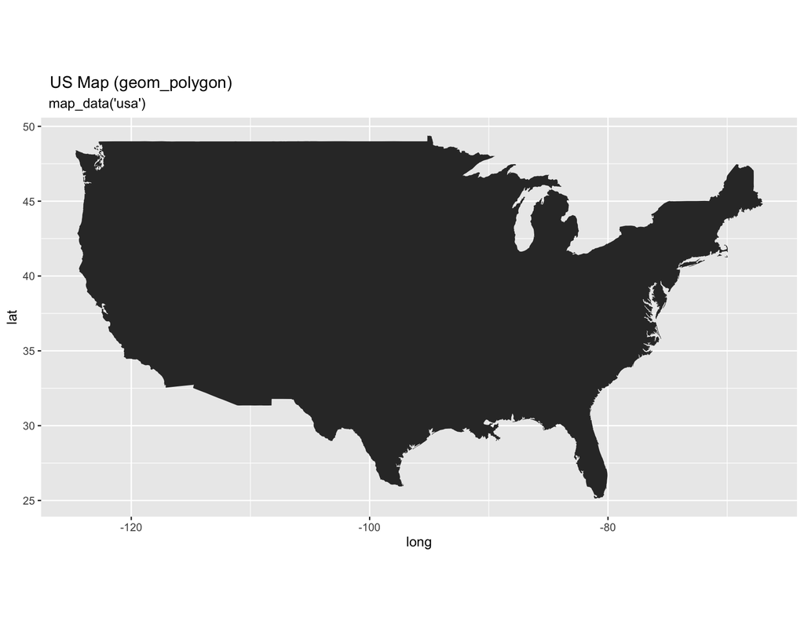

```r
labs_geom_polygon_usa <- ggplot2::labs(
  title = "  US Map (geom_polygon)",
  subtitle = "  map_data('usa')")
USmap %>%
  ggplot2::ggplot() +
  ggplot2::geom_polygon(aes(x = long,
                            y = lat,
                            group = group)) +
  ggplot2::coord_quickmap() +
  labs_geom_polygon_usa
```

Once again we see this map of the US needs some customizing, so we include the `fill`, `color`, and `alpha` arguments.

### 3.7.2 Customizing US map

1. add `fill`, `color` and `alpha` arguments to lighten the color of the continents
2. Include the `ggplot2::theme_void()` layer (specifically designed to remove excess chart junk and give it a ‘minimal’ look)
3. Include labels

Save this as `ggp_us_map`

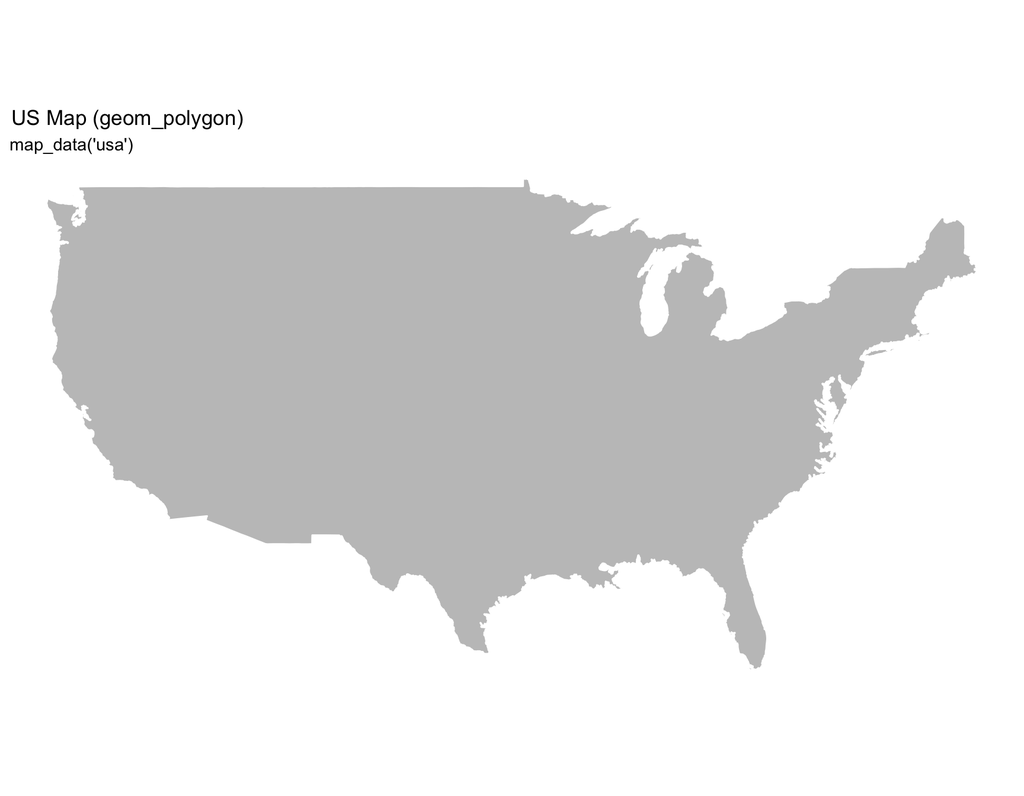

```r
ggp_us_map <- USmap %>%
  ggplot2::ggplot() +
  ggplot2::geom_polygon(aes(x = long,
                            y = lat,
                            group = group),
                        fill = "grey70", color = "white", alpha = 0.8) +
  ggplot2::coord_quickmap() +
  ggplot2::theme_void() +
  labs_geom_polygon_usa
ggp_us_map
```

## 3.8 Adding twitter data (US)

Now we have a canvas to work with–lets filter the `TweetsMap` data to only those tweets from the US using the `country_code` (first we count this variable to see what the codes are).

```r
TweetsMap %>%
  count(country_code, sort = TRUE)
```

| country_code | n |
| --- | --- |
| US | 150 |
| MX | 16 |
| GB | 11 |
| JP | 8 |
| BR | 6 |
| AT | 1 |
| AU | 1 |
| CA | 1 |
| IE | 1 |
| IL | 1 |

[output cut: 1 more lines]

It looks like we have 150 tweets from the US–we will store these data in `UsTweets`

```r
UsTweets <- TweetsMap %>% filter(country_code == "US")
glimpse(UsTweets)
```

```
## Rows: 150
## Columns: 12
## $ user_id        <chr> "1391401897035243527", "1485612379"…
## $ created_at     <dttm> 2021-11-08 05:37:26, 2021-11-08 05…
## $ screen_name    <chr> "BarstoolMKE1", "amandaheger613", "…
## $ text           <chr> "BREAKING: Sports media taking Mond…
## $ retweet_count  <int> 0, 0, 0, 0, 0, 1, 0, 0, 1, 0, 0, 0,…
## $ favorite_count <int> 0, 0, 0, 0, 2, 2, 1, 1, 2, 0, 0, 90…
## $ country        <chr> "United States", "United States", "…
## $ location       <chr> "Milwaukee, WI", "Goodyear, AZ", "G…
## $ country_code   <chr> "US", "US", "US", "US", "US", "US",…
## $ friends_count  <int> 278, 40, 40, 3156, 1424, 3282, 1989…
## $ lat            <dbl> 43.06754, 33.41287, 33.41287, 32.81…
## $ long           <dbl> -88.02554, -112.42498, -112.42498, …
```

We will updated the labels for the US map.

### 3.8.1 US twitter data (`geom_polygon()`)

1. Create new labels
2. Add a `geom_point()` layer to the existing `ggp_us_map`
3. Include the `data = UsTweets` argument at this layer, and specify the `x = long` and `y = lat`
4. Add labels

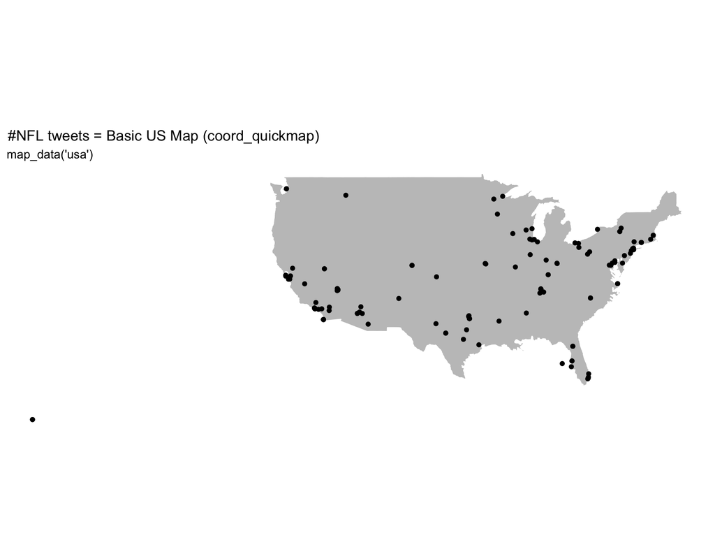

```r
# new labels
labs_coord_quickmap_tweets_usa <- ggplot2::labs(
  title = "  #NFL tweets = Basic US Map (coord_quickmap)",
  subtitle = "  map_data('usa')")

ggp_us_map +
  # twitter data layer
  ggplot2::geom_point(data = UsTweets,
                      aes(x = long, y = lat)) +
  ggplot2::theme_void() +
  labs_coord_quickmap_tweets_usa
```

We can see this map output is including the tweets from Hawaii (which is skewing the map projection), so we will combine `ggplot2`s layers and `dplyr`s data manipulation functions together to remove these points *without* changing the data in `UsTweets`.

### 3.8.2 Locate outliers

We can use `str_view_all()` to take a look at the `location` variable and see if we can find the Hawaii location:

```r
# search for ", HI" pattern
str_view_all(string = UsTweets$location, pattern = ", HI", match = TRUE)
```

[interactive chart not shown]

We can see two tweets with `location` as `Honolulu, HI`, so we will `filter()` these data *inside* the `geom_point()` layer in the `data` argument.

1. Create new labels
2. Use `!str_detect()` to remove any observations that match the `Honolulu, HI` pattern
3. Change the `size` of the points to `0.9` and the `color` of the points to `"firebrick"`
4. Add theme
5. Add labels

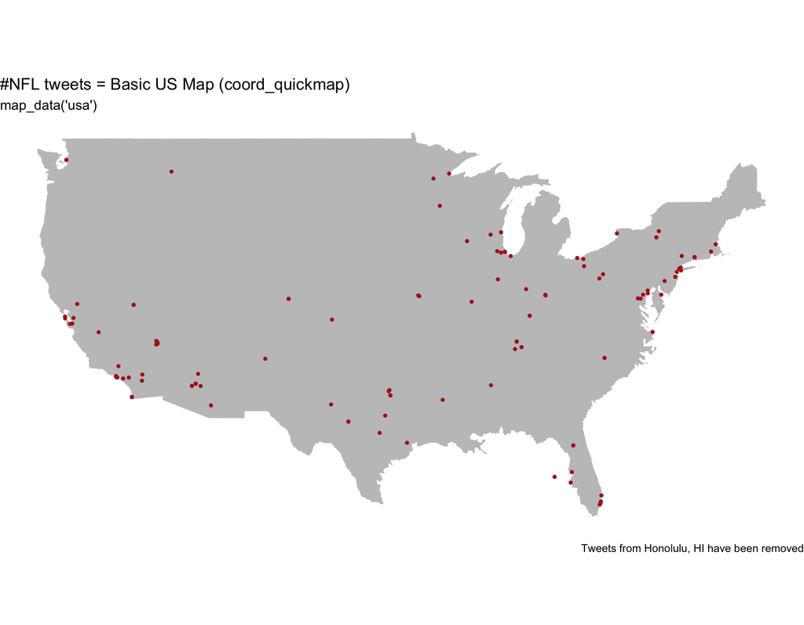

```r
labs_coord_quickmap_no_hi <- ggplot2::labs(
  title = "#NFL tweets = Basic US Map (coord_quickmap)",
  subtitle = "map_data('usa')",
  caption = "Tweets from Honolulu, HI have been removed")

ggp_us_map +
  ggplot2::geom_point(
    data = filter(UsTweets,
                  !str_detect(location, "Honolulu, HI")),
                      aes(x = long, y = lat),
                      size = 0.9, # reduce size of points
                      color = "firebrick") +
  ggplot2::theme_void() +
  labs_coord_quickmap_no_hi
```

This is looking better, but we should recall we have a few additional variables on the tweets in `UsTweets`. Let’s use what we’ve learned in previous lessons/exercises to view the distribution of `favorite_count` across the various locations in `UsTweets`.

### 3.8.3 Distribution of `favorite_count`

1. Build labels
2. Pipe the `UsTweets` data to `filter()` and remove the tweets from Hawaii
3. Initiate the plot with `ggplot()` and assign `favorite_count` to the `x` aesthetic
4. Add a `geom_density()` layer
5. Add `facet_wrap()` and facet the plots by `location`
6. Include a `theme_minimal()` to reduce the chart elements
7. Add labels

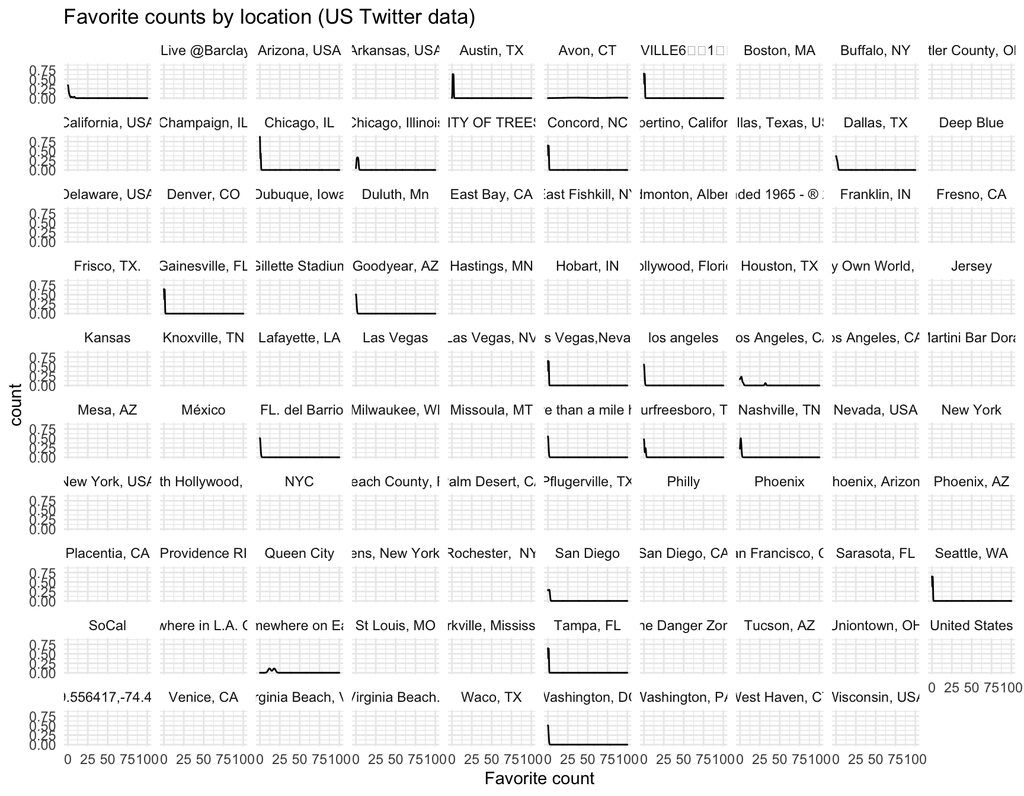

```r
labs_facet_wrap_favorite_count <- ggplot2::labs(
  title = "Favorite counts by location (US Twitter data)",
  x = "Favorite count",
  y = "count"
)

UsTweets %>%
  filter(!str_detect(location, "Honolulu, HI")) %>%
  ggplot(aes(x = favorite_count)) +
  geom_density() +
  facet_wrap(. ~ location) +
  theme_minimal() +
  labs_facet_wrap_favorite_count
```

One of the drawbacks of the density plot is that the `y` axis is hard to interpret, but it’s OK in this case, because this graph is telling us all we need to know: **Some of these aren’t like the others**

### 3.8.4 Add `favorite_count` to US Map

If we want to add the `favorite_count` variable to the plot, we can do this with the size argument in `geom_point()`, which will make the size of the point relative to the number of `favorite_count` at each `long` and `lat`.

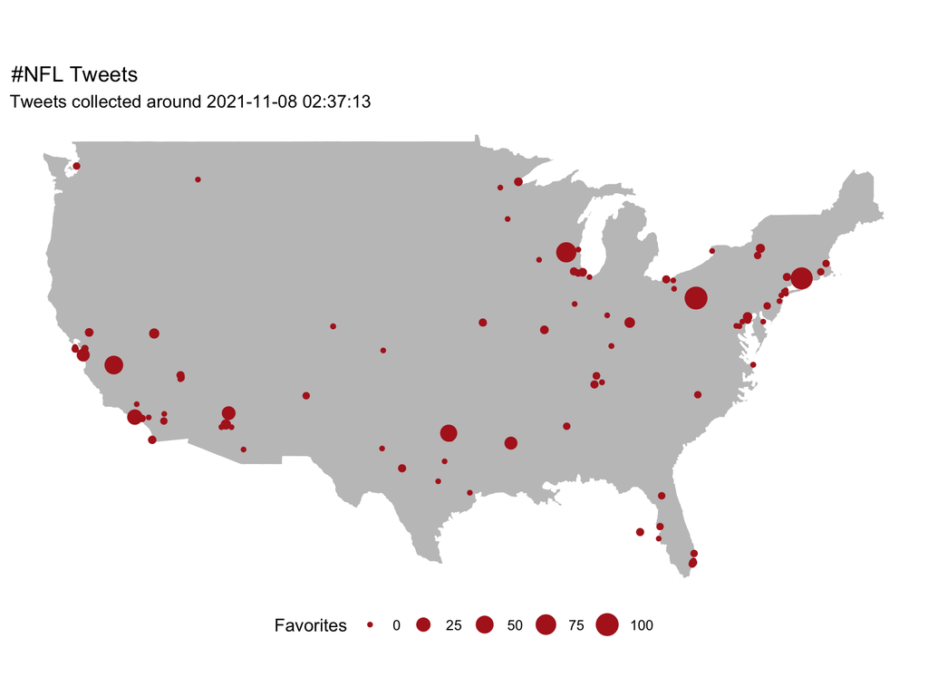

```r
labs_coord_quickmap_favs <- ggplot2::labs(
  title = "  #NFL Tweets",
  subtitle = paste0("  Tweets collected around ",
                    mean(UsTweets$created_at, na.rm = TRUE)),
  size = "Favorites")

ggp_us_map +
  ggplot2::geom_point(
    data = filter(UsTweets,
                  !str_detect(location, "Honolulu, HI")),
      aes(x = long,
          y = lat,
          size = favorite_count),
          color = "firebrick") +
  theme(legend.position = 'bottom') +
  labs_coord_quickmap_favs
```

## 3.9 Summary

This has been a very short introduction to maps with `ggplot2`. In the next lesson, we will introduce how to make maps with `leaflet` and `plotly`, two popular mapping packages for creating interactive maps.

Be sure to check out the resources below for building maps:

1. The [maps chapter of the ggplot2 book](https://ggplot2-book.org/maps.html#maps)
2. The [draw maps chapter of Data Visualization: A practical introduction](https://socviz.co/maps.html#maps)
3. [This tutorial](https://r-spatial.org/r/2018/10/25/ggplot2-sf.html) from r-spatial for extending ggplot2 with maps